# INFO-2950-Final-Project

## Link to Google Drive Folder w/ Files:

https://drive.google.com/drive/folders/1vijUMhDe9qtJcSmORocCwUis7_dg3ziM?usp=sharing

## GitHub Repository:

https://github.coecis.cornell.edu/wf74/info2950project

# Introduction

## Research Questions:

- Is there racial profiling in policing?
- Is racial bias affected by location?
  - Does a city in the south (Austin,TX) arrest more minorities than one in the north (New York City, NY) or vice versa?

## Initial Problems:

- Years of Arrest Records do not match up exactly
  - APD: 2014-2019
  - NYPD: 2006-2019
- Census data is from 2010, bit earlier than arrest records
- Some of the APD arrest record CSVs use different columns names
  - Mainly focused on "APD_RACE_DESC" which is consistent across all CSV files
- Only pulled only Black or White ethnicites so far, not accounting for mixed races, which are recorded in both census and arrest data
  - Could do White vs. Everything else so that it is more general for minorities, rather than just Black or African American ethnicity

  When exploring racial bias in policing, it is obvious that there will be many factors which could induce an encounter where there is obvious racial bias. That specific officer's predisposition towards other races, current cultural influence, how violent the crime is, etc. Thus, there are far too many factors to ever concusively say that a specific police department or region has a racial bias issue.

  One might be able to say that a disproportionate number of minorities or a specific race are arrested in a certain time frame, but one cannot claim a consistent issue with racial bias in a police department from that analysis. In my opinion, there would need to be an overwhelming number, the majority of police encounters, each individually examined and proven by experts to have racial bias issues involved, to be able to claim there is a consistent, widespread issue. My point is that each arrest is so nuanced that any reasonable claims about the racial bias of an entire police department would be near impossible.

  Thus, the best way to find significant analysis from this dataset would be to look at number of arrests for each race, over time. This can tell us if there are any races that are arrested more often than others and if this trend is consistent over time; if there is any change in this trend over time. The census data was found in order to give context. If there is a discrepany between the percentage of a certain race in the census versus the arrest records, this could further strengthen the claim of racial bias. It is near impossible to fully prove that there is racial bias, but proving trends exist through significant statistical analysis can make the claim more credible.

## Initial Questions:

- Do I need to include mixed races? Is black vs. white ethnicity efficient or would it be better to do white vs. minorities?
- How can I implement the data about their offense? The race known value?
- Is there a better way to show the data with a bar chart? Include more ethnicites here? Could show data from both areas on one bar chart.

# Data Description

## Arrest Records:

- Observations: Individual Arrests
- Important Attributes:
  - APD: APD_RACE_DESC, REASON_FOR_STOP_DESC
  - NYPD: PERP_RACE, OFNS_DESC
- Both datasets were created with the intention to examine racial profiling in those police departments.
- Published by: data.austintexas.gov, funded by the government?
- The arrest record data is dependent on accurate police reports, which could have issues with human error or even officers trying to reduce the perception of racial profiling.
- Not much preprocessing, data includes primary key codes and descriptions that look like they were pulled directly from reports.
- Other than the police officer and whoever processes police reports, there was no human influence. Atleast in the process of pulling data from police reports, which was most likely done by a machine.
- Links:
  - NYPD Arrest (2006 - 2019):
    - NYPD Arrests: https://catalog.data.gov/dataset/nypd-arrests-data-historic
    - NYPD Arrests Description and Legend: https://data.cityofnewyork.us/Public-Safety/NYPD-Arrests-Data-Historic-/8h9b-rp9u
  - APD (2014 - 2019):
    - 2014 APD Arrests: https://catalog.data.gov/dataset/2014-racial-profiling-arrests
    - 2014 APD Arrests Description and Legend: https://data.austintexas.gov/Public-Safety/2014-Racial-Profiling-Arrests/fk9e-2udt
    - 2015 APD Arrests: https://catalog.data.gov/dataset/2015-racial-profiling-arrests
    - 2015 APD Arrests Description and Legend: https://data.austintexas.gov/Public-Safety/2015-Racial-Profiling-Arrests/nbjz-52e4
    - 2016 APD Arrests: https://catalog.data.gov/dataset/2016-rp-arrests
    - 2016 APD Arrests Description and Legend: https://data.austintexas.gov/Public-Safety/2016-RP-Arrests/bmz9-cdnt
    - 2017 APD Arrests: https://catalog.data.gov/dataset/2017-racial-profiling-arrests
    - 2017 APD Arrests Description and Legend: https://data.austintexas.gov/Public-Safety/2017-Racial-Profiling-Arrests/x4p3-hj3y
    - 2018 APD Arrests: https://catalog.data.gov/dataset/2018-rp-arrests
    - 2018 APD Arrests Description and Legend: https://data.austintexas.gov/Public-Safety/2018-RP-Arrests/xfke-9bsj
    - 2019 APD Arrests: https://catalog.data.gov/dataset/2019-racial-profiling-rp-arrests
    - 2019 APD Arrests Description and Legend: https://data.austintexas.gov/Public-Safety/2019-Racial-Profiling-RP-Arrests/m4cc-q8pr

## Census Data:

- Observations: Age Groups in a given county
- Important Attributes:
  - There are many different types of ethnicities listed in the census data
  - Mainly focused on BA_MALE, BA_FEMALE WA_MALE, WA_FEMALE
  - BA = Black or African American alone, WA = White alone
  - These are people that are only black or african american, or white, no mixed ethnicities included so far
- Dataset was created and as part of the 2010 US Census.
- Funded and published by the US Census Bureau.
- If people didn't respond to the census, they wouldn't have been counted.
- There was not much preprocessing, just aggregation of reports from people collecting the census data.
- There could be human error here with the people collecting the census data.
- Links:
  - Census Dataset: https://www2.census.gov/programs-surveys/popest/datasets/2000-2010/intercensal/county/
  - Austin Census (2000-2010): https://www2.census.gov/programs-surveys/popest/datasets/2000-2010/intercensal/county/co-est00int-alldata-48.csv
    - co-est00int-alldata-48.csv
  - NYC Census (2000-2010): https://www2.census.gov/programs-surveys/popest/datasets/2000-2010/intercensal/county/co-est00int-alldata-36.csv
    - co-est00int-alldata-36.csv
  - Census Legend: https://www2.census.gov/programs-surveys/popest/datasets/2000-2010/intercensal/county/co-est00int-alldata-4-25-13.pdf
    - co-est00int-alldata-4-25-13.csv
  - NYPD Penal Code: http://ypdcrime.com/penal.law/offense_level.htm
    - "Felony" means an offense for which a sentence to a term of imprisonment in excess of one year may be imposed.
    - "Misdemeanor" means an offense, other than a "traffic infraction," for which a sentence to a term of imprisonment in excess of fifteen days may be imposed, but for which a sentence to a term of imprisonment in excess of one year cannot be imposed.
    - "Violation" means an offense, other than a "traffic infraction," for which a sentence to a term of imprisonment in excess of fifteen days cannot be imposed.
    - "Traffic Infraction" means any offense defined as "traffic infraction" by section one hundred fifty-five of the vehicle and traffic law.

## Project Phase III: Preregistration of analyses

Analysis 1: Which ethnicity is arrested more often in each city? Is this consistent with the breakdown of ethnicities from the census data?

```
    Steps:
        - Find percentage that each minority is arrested for each arrest record dataset.
        - Find breakdown of race in terms of percentage for the census data.
        - Compare the percentages from the arrest records to the percentages from the census data.

    - Outcomes: One cannot take this analysis as concrete evidence that there is racial bias, but we should be able to agree that if there is systematic racial bias in policing, a minority group, such as African Americans, would be arrested more than White people. There are many factors to consider here and to really find concrete evidence of racial bias, one would need to examine every arrest individually.
```

Analysis 2: Specifically looking at African Americans and crimes that don't always warrant arrest, is there a difference in the number of African Americans vs. White people that are arrested for these crimes?

```
    Steps:
        - Need to identify which crimes are not likely to result in arrest
        - Split dataset into just those crimes
        - Find breakdown of these two ethnicities

    - Outcomes: I think identifying which crimes are "less significant" would be difficult and could easily be debated, but we can probably agree that a race being systematically opressed by bias in policing would be arrested more for the smaller, more petty crimes, as the officers would be looking to arrest them on anything. I don't know how significant this analysis can be, certainly less than the other two.
```

Analysis 3: Find ratio between black vs. white arrests in each city and compare that to the census data. Then, compare how close the arrest data ratio is to the census data for each city, to find is there is a geographical impact on racial bias.

```
    Steps:
        - Find number of arrest records that indicate black and white as race for each city.
        - Find the census records that indicate black and white as race for each city.
        - See how close these percentages/ratios are to each other. Find the difference between them for each city (arrest vs. census race breakdown).
        - Compare the difference between arrests and census data for each city to one another. This should allow for a conclusion on the location having an impact on racial bias, assuming a large difference between census race percentages and arrest record race percentages.

    - Outcomes: If there is a large difference between the race breakdown for the census vs. arrest records in one city, and a very small difference in another, one cannot make any concrete statements, but might assume that there is racial bias, due to the difference between arrest records and the census data.
```

### Questions (post Phase 3):

- Do you think it is significant enough analysis to make the connection between census data and arrest records? Is it a bad idea to base my overall analysis on a difference in race percentages between the two?
- Can you think of any uniform way to classify the lesser crimes that I want to examine?
- Are there any other variables you see that you think I should include in analysis?

```python
import numpy as np
import pandas as pd
import matplotlib.pyplot as plt
import seaborn as sns
```

```python
APD_arrests2014 = pd.DataFrame(pd.read_csv("C:/Users/wf74/Desktop/INFO 2950/project/2014_apd.csv"))
APD_arrests2015 = pd.DataFrame(pd.read_csv("C:/Users/wf74/Desktop/INFO 2950/project/2015_apd.csv"))
APD_arrests2016 = pd.DataFrame(pd.read_csv("C:/Users/wf74/Desktop/INFO 2950/project/2016_apd.csv"))
APD_arrests2017 = pd.DataFrame(pd.read_csv("C:/Users/wf74/Desktop/INFO 2950/project/2017_apd.csv"))
APD_arrests2018 = pd.DataFrame(pd.read_csv("C:/Users/wf74/Desktop/INFO 2950/project/2018_apd.csv"))
APD_arrests2019 = pd.DataFrame(pd.read_csv("C:/Users/wf74/Desktop/INFO 2950/project/2019_apd.csv"))
NYPD_arrests = pd.DataFrame(pd.read_csv("C:/Users/wf74/Desktop/INFO 2950/project/all_nypd.csv"))
NY_census = pd.DataFrame(pd.read_csv("C:/Users/wf74/Desktop/INFO 2950/project/ny_census.csv"))
TX_census = pd.DataFrame(pd.read_csv("C:/Users/wf74/Desktop/INFO 2950/project/tx_census.csv"))
```

```python
APD_arrests = pd.concat([APD_arrests2014, APD_arrests2015, APD_arrests2016, APD_arrests2017, APD_arrests2018, APD_arrests2019])
```

```python
APD_arrests.head()
```

|  | PRIMARY_KEY | SEX | APD_RACE_DESC | PERSON_SEARCHED_DESC | REASON_FOR_STOP_DESC | SEARCH_BASED_ON_DESC | SEARCH_DISC_DESC | RACE_KNOWN | SECTOR | REP_DATE | ... | CAD_sector | CouncilDistrict | APD_sector | county_description | ZIP | CENSUS_TRACT | Reason for Stop – TCOLE form | Person Search YN | Search Based On | Search Found |
| --- | --- | --- | --- | --- | --- | --- | --- | --- | --- | --- | --- | --- | --- | --- | --- | --- | --- | --- | --- | --- | --- |
| 0 | 201411372 | F | BLACK | YES = 1 | VIOLATION OF TRANSPORTATION CODE/VEHICLE LAWS | PROBABLE CAUSE | NOTHING | YES - RACE OR ETHNICITY WAS KNOWN BEFORE STOP | CHARLIE | NaN | ... | NaN | NaN | NaN | NaN | NaN | NaN | NaN | NaN | NaN | NaN |
| 1 | 201411525 | M | BLACK | YES = 1 | VIOLATION OF TRANSPORTATION CODE/VEHICLE LAWS | PROBABLE CAUSE | DRUGS | NO - RACE OR ETHNICITY WAS NOT KNOWN BEFORE STOP | CHARLIE | NaN | ... | NaN | NaN | NaN | NaN | NaN | NaN | NaN | NaN | NaN | NaN |
| 2 | 201411525 | M | BLACK | YES = 1 | VIOLATION OF TRANSPORTATION CODE/VEHICLE LAWS | PROBABLE CAUSE | DRUGS | NO - RACE OR ETHNICITY WAS NOT KNOWN BEFORE STOP | CHARLIE | NaN | ... | NaN | NaN | NaN | NaN | NaN | NaN | NaN | NaN | NaN | NaN |
| 3 | 201410592 | M | HISPANIC OR LATINO | YES = 1 | VIOLATION OF TRANSPORTATION CODE/VEHICLE LAWS | INCIDENTAL TO ARREST | NOTHING | NO - RACE OR ETHNICITY WAS NOT KNOWN BEFORE STOP | BAKER | NaN | ... | NaN | NaN | NaN | NaN | NaN | NaN | NaN | NaN | NaN | NaN |
| 4 | 201411940 | M | BLACK | YES = 1 | PRE-EXISTING KNOWLEDGE | INCIDENTAL TO ARREST | CASH | NO - RACE OR ETHNICITY WAS NOT KNOWN BEFORE STOP | IDA | NaN | ... | NaN | NaN | NaN | NaN | NaN | NaN | NaN | NaN | NaN | NaN |

5 rows × 28 columns

```python
NYPD_arrests.head()
```

|  | ARREST_KEY | ARREST_DATE | PD_CD | PD_DESC | KY_CD | OFNS_DESC | LAW_CODE | LAW_CAT_CD | ARREST_BORO | ARREST_PRECINCT | JURISDICTION_CODE | AGE_GROUP | PERP_SEX | PERP_RACE | X_COORD_CD | Y_COORD_CD | Latitude | Longitude | Lon_Lat |
| --- | --- | --- | --- | --- | --- | --- | --- | --- | --- | --- | --- | --- | --- | --- | --- | --- | --- | --- | --- |
| 0 | 144026181 | 06/26/2015 | 639.0 | AGGRAVATED HARASSMENT 2 | 361.0 | OFF. AGNST PUB ORD SENSBLTY & RGHTS TO PRIV | PL 2403002 | M | Q | 102 | 0.0 | 45-64 | M | WHITE HISPANIC | 1031076.0 | 193779.0 | 40.698440 | -73.831130 | POINT (-73.83112953899997 40.69843969400005) |
| 1 | 144507595 | 07/14/2015 | 969.0 | TRAFFIC,UNCLASSIFIED INFRACTION | 881.0 | OTHER TRAFFIC INFRACTION | VTL051101A | M | M | 10 | 3.0 | 25-44 | M | WHITE HISPANIC | 984791.0 | 209846.0 | 40.742664 | -73.998049 | POINT (-73.99804910799998 40.74266360800004) |
| 2 | 144565062 | 07/16/2015 | 101.0 | ASSAULT 3 | 344.0 | ASSAULT 3 & RELATED OFFENSES | PL 1200001 | M | K | 90 | 0.0 | 18-24 | F | WHITE HISPANIC | 994026.0 | 195548.0 | 40.703414 | -73.964743 | POINT (-73.96474295699994 40.70341366900004) |
| 3 | 144500188 | 07/14/2015 | 879.0 | ADM.CODE,UNCLASSIFIED VIOLATION | 675.0 | ADMINISTRATIVE CODE | AC 010125B | V | Q | 103 | 0.0 | 25-44 | M | WHITE HISPANIC | 1037132.0 | 196129.0 | 40.704856 | -73.809271 | POINT (-73.809270971 40.70485576300007) |
| 4 | 144216044 | 07/03/2015 | 478.0 | THEFT OF SERVICES, UNCLASSIFIED | 343.0 | OTHER OFFENSES RELATED TO THEFT | PL 1651503 | M | M | 10 | 1.0 | 18-24 | M | WHITE HISPANIC | 984602.0 | 210686.0 | 40.744969 | -73.998731 | POINT (-73.99873112099993 40.74496920800005) |

```python
NY_census.head()
```

|  | SUMLEV | STATE | COUNTY | STNAME | CTYNAME | YEAR | AGEGRP | TOT_POP | TOT_MALE | TOT_FEMALE | ... | HBA_MALE | HBA_FEMALE | HIA_MALE | HIA_FEMALE | HAA_MALE | HAA_FEMALE | HNA_MALE | HNA_FEMALE | HTOM_MALE | HTOM_FEMALE |
| --- | --- | --- | --- | --- | --- | --- | --- | --- | --- | --- | --- | --- | --- | --- | --- | --- | --- | --- | --- | --- | --- |
| 0 | 50 | 36 | 1 | New York | Albany County | 1 | 0 | 3192 | 1662 | 1530 | ... | 41 | 23 | 1 | 0 | 2 | 2 | 0 | 0 | 11 | 3 |
| 1 | 50 | 36 | 1 | New York | Albany County | 1 | 1 | 13458 | 6949 | 6509 | ... | 119 | 91 | 10 | 2 | 1 | 5 | 1 | 0 | 29 | 24 |
| 2 | 50 | 36 | 1 | New York | Albany County | 1 | 2 | 18948 | 9770 | 9178 | ... | 127 | 119 | 11 | 4 | 5 | 5 | 3 | 2 | 34 | 22 |
| 3 | 50 | 36 | 1 | New York | Albany County | 1 | 3 | 19435 | 9968 | 9467 | ... | 109 | 87 | 11 | 12 | 4 | 3 | 4 | 0 | 21 | 30 |
| 4 | 50 | 36 | 1 | New York | Albany County | 1 | 4 | 22230 | 11153 | 11077 | ... | 106 | 108 | 7 | 6 | 5 | 3 | 3 | 3 | 25 | 17 |

5 rows × 50 columns

```python
TX_census.head()
```

|  | SUMLEV | STATE | COUNTY | STNAME | CTYNAME | YEAR | AGEGRP | TOT_POP | TOT_MALE | TOT_FEMALE | ... | HBA_MALE | HBA_FEMALE | HIA_MALE | HIA_FEMALE | HAA_MALE | HAA_FEMALE | HNA_MALE | HNA_FEMALE | HTOM_MALE | HTOM_FEMALE |
| --- | --- | --- | --- | --- | --- | --- | --- | --- | --- | --- | --- | --- | --- | --- | --- | --- | --- | --- | --- | --- | --- |
| 0 | 50 | 48 | 1 | Texas | Anderson County | 1 | 0 | 618 | 311 | 307 | ... | 1 | 1 | 0 | 3 | 0 | 0 | 1 | 1 | 1 | 1 |
| 1 | 50 | 48 | 1 | Texas | Anderson County | 1 | 1 | 2419 | 1228 | 1191 | ... | 6 | 7 | 4 | 1 | 0 | 0 | 0 | 1 | 4 | 3 |
| 2 | 50 | 48 | 1 | Texas | Anderson County | 1 | 2 | 3061 | 1638 | 1423 | ... | 5 | 8 | 0 | 3 | 0 | 0 | 0 | 1 | 4 | 2 |
| 3 | 50 | 48 | 1 | Texas | Anderson County | 1 | 3 | 3250 | 1627 | 1623 | ... | 4 | 3 | 0 | 4 | 0 | 0 | 0 | 0 | 3 | 0 |
| 4 | 50 | 48 | 1 | Texas | Anderson County | 1 | 4 | 3310 | 1727 | 1583 | ... | 6 | 3 | 4 | 3 | 1 | 4 | 0 | 0 | 1 | 4 |

5 rows × 50 columns

```python
# Separate rows for Austin County
ATX_census = TX_census[TX_census['CTYNAME'] == 'Austin County']
ATX_census.head()
```

|  | SUMLEV | STATE | COUNTY | STNAME | CTYNAME | YEAR | AGEGRP | TOT_POP | TOT_MALE | TOT_FEMALE | ... | HBA_MALE | HBA_FEMALE | HIA_MALE | HIA_FEMALE | HAA_MALE | HAA_FEMALE | HNA_MALE | HNA_FEMALE | HTOM_MALE | HTOM_FEMALE |
| --- | --- | --- | --- | --- | --- | --- | --- | --- | --- | --- | --- | --- | --- | --- | --- | --- | --- | --- | --- | --- | --- |
| 1820 | 50 | 48 | 15 | Texas | Austin County | 1 | 0 | 291 | 157 | 134 | ... | 1 | 0 | 0 | 0 | 0 | 0 | 1 | 0 | 0 | 0 |
| 1821 | 50 | 48 | 15 | Texas | Austin County | 1 | 1 | 1271 | 646 | 625 | ... | 11 | 3 | 3 | 2 | 0 | 2 | 0 | 1 | 1 | 1 |
| 1822 | 50 | 48 | 15 | Texas | Austin County | 1 | 2 | 1734 | 880 | 854 | ... | 9 | 3 | 1 | 4 | 0 | 0 | 0 | 1 | 1 | 1 |
| 1823 | 50 | 48 | 15 | Texas | Austin County | 1 | 3 | 1861 | 963 | 898 | ... | 2 | 1 | 4 | 1 | 0 | 0 | 0 | 0 | 0 | 1 |
| 1824 | 50 | 48 | 15 | Texas | Austin County | 1 | 4 | 1877 | 975 | 902 | ... | 0 | 3 | 1 | 0 | 0 | 0 | 0 | 0 | 0 | 0 |

5 rows × 50 columns

```python
# Take counties that correspond with 5 boroughs of NYC
NYC_census = NY_census[(NY_census['CTYNAME'] == 'Kings County') | (NY_census['CTYNAME'] == 'New York County') | (NY_census['CTYNAME'] == 'Richmond County') | (NY_census['CTYNAME'] == 'Queens County') | (NY_census['CTYNAME'] == 'Bronx County')].copy()
NYC_census.head()
```

|  | SUMLEV | STATE | COUNTY | STNAME | CTYNAME | YEAR | AGEGRP | TOT_POP | TOT_MALE | TOT_FEMALE | ... | HBA_MALE | HBA_FEMALE | HIA_MALE | HIA_FEMALE | HAA_MALE | HAA_FEMALE | HNA_MALE | HNA_FEMALE | HTOM_MALE | HTOM_FEMALE |
| --- | --- | --- | --- | --- | --- | --- | --- | --- | --- | --- | --- | --- | --- | --- | --- | --- | --- | --- | --- | --- | --- |
| 520 | 50 | 36 | 5 | New York | Bronx County | 1 | 0 | 21409 | 10831 | 10578 | ... | 1460 | 1436 | 118 | 115 | 45 | 46 | 16 | 32 | 184 | 163 |
| 521 | 50 | 36 | 5 | New York | Bronx County | 1 | 1 | 88290 | 44963 | 43327 | ... | 6256 | 5895 | 464 | 483 | 131 | 166 | 128 | 113 | 719 | 700 |
| 522 | 50 | 36 | 5 | New York | Bronx County | 1 | 2 | 119731 | 61008 | 58723 | ... | 8402 | 8110 | 698 | 643 | 180 | 200 | 194 | 140 | 845 | 826 |
| 523 | 50 | 36 | 5 | New York | Bronx County | 1 | 3 | 107786 | 54982 | 52804 | ... | 7164 | 6898 | 613 | 562 | 175 | 198 | 147 | 143 | 744 | 714 |
| 524 | 50 | 36 | 5 | New York | Bronx County | 1 | 4 | 101223 | 51544 | 49679 | ... | 6089 | 6206 | 547 | 494 | 160 | 180 | 130 | 125 | 632 | 629 |

5 rows × 50 columns

```python
# Atot == sum of total populations for all age groups in Austin County
Atot = ATX_census['TOT_POP'].sum()
print(Atot)
```

```
683214
```

```python
# AtotB == sum of black or african american males and females across all age groups in Austin County
AtotBmale = ATX_census['BA_MALE'].sum()
AtotBfemale = ATX_census['BA_FEMALE'].sum()
AtotB = AtotBmale + AtotBfemale
print(AtotB)
```

```
69964
```

```python
ApB = (AtotB / Atot) * 100
print("Percent of Black or African American alone in Austin County: {:.2f}%".format(ApB))
```

```
Percent of Black or African American alone in Austin County: 10.24%
```

```python
# AtotW == sum of white males and females across all age groups in Austin County
AtotWmale = ATX_census['WA_MALE'].sum()
AtotWfemale = ATX_census['WA_FEMALE'].sum()
AtotW = AtotWmale + AtotWfemale
print(AtotW)
```

```
600112
```

```python
ApW = (AtotW / Atot) * 100
print("Percent of White alone: {:.2f}%".format(ApW))
```

```
Percent of White alone: 87.84%
```

```python
ApTotal = ((AtotB + AtotW)/Atot)*100
print("White alone and Black or African American alone make up {:.2f}% of total population in Austin County.".format(ApTotal))
```

```
White alone and Black or African American alone make up 98.08% of total population in Austin County.
```

```python
# Ntot == sum of total populations for all age groups in all New York City counties in 2010
Ntot = NYC_census['TOT_POP'].sum()
print(Ntot)
```

```
209701790
```

```python
# NtotB == sum of black or african american males and females across all age groups in New York City counties
NtotBmale = NYC_census['BA_MALE'].sum()
NtotBfemale = NYC_census['BA_FEMALE'].sum()
NtotB = NtotBmale + NtotBfemale
print(NtotB)
```

```
61595672
```

```python
NpB = (NtotB / Ntot) * 100
print("Percent of Black or African American alone in New York City counties: {:.2f}%".format(NpB))
```

```
Percent of Black or African American alone in New York City counties: 29.37%
```

```python
# NtotW == sum of white males and females across all age groups in New York City counties
NtotWmale = NYC_census['WA_MALE'].sum()
NtotWfemale = NYC_census['WA_FEMALE'].sum()
NtotW = NtotWmale + NtotWfemale
print(NtotW)
```

```
115994048
```

```python
NpW = (NtotW / Ntot) * 100
print("Percent of White alone in New York City counties: {:.2f}%".format(NpW))
```

```
Percent of White alone in New York City counties: 55.31%
```

```python
NpTotal = ((NtotB + NtotW)/Ntot)*100
print("White alone and Black or African American alone make up {:.2f}% of total population in New York City counties.".format(NpTotal))
```

```
White alone and Black or African American alone make up 84.69% of total population in New York City counties.
```

```python
# Put percentages of black/white into dataframe
pBW_census = pd.DataFrame({'Austin': [ApB, ApW], 'NYC': [NpB, NpW]}, index=['Black or African American alone', 'White alone'])
```

```
array([<AxesSubplot:ylabel='Austin'>, <AxesSubplot:ylabel='NYC'>],
      dtype=object)
```

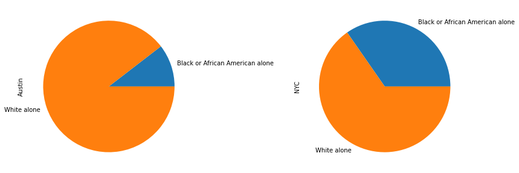

```python
# Pie plots showing breakdown of white vs. black ethnicity in the two areas
pBW_census.plot.pie(subplots=True, legend=None, figsize=(15,5))
```

```python
# Total number of Arrests in Austin County from 2014-2019
APDtot = len(APD_arrests.index)
print(APDtot)
```

```
60734
```

```python
# Total number of Black people arrested in Austin County from 2014-2019
APDtotB = len(APD_arrests[APD_arrests['APD_RACE_DESC'] == 'BLACK'])
print(APDtotB)
```

```
14739
```

```python
# Total number of White people arrested in Austin County from 2014-2019
APDtotW = len(APD_arrests[APD_arrests['APD_RACE_DESC'] == 'WHITE'])
print(APDtotW)
```

```
19934
```

```python
# Pecent of people arrests whose ethnicity was listed as Black
APDpB = (APDtotB / APDtot) * 100
print("Percent of people arrested in Austin County from 2014-2019 that were Black: {:.2f}%".format(APDpB))
```

```
Percent of people arrested in Austin County from 2014-2019 that were Black: 24.27%
```

```python
# Pecent of people arrests whose ethnicity was listed as White
APDpW = (APDtotW / APDtot) * 100
print("Percent of people arrested in Austin County from 2014-2019 that were White: {:.2f}%".format(APDpW))
```

```
Percent of people arrested in Austin County from 2014-2019 that were White: 32.82%
```

```python
APDpTotal = ((APDtotB + APDtotW)/APDtot)*100
print("People of White and Black ethnicities make up {:.2f}% of total arrests in Austin County from 2014-2019.".format(APDpTotal))
```

```
People of White and Black ethnicities make up 57.09% of total arrests in Austin County from 2014-2019.
```

```python
# Total number of Arrests in New York City counties from 2011-2015
NYPDtot = len(NYPD_arrests.index)
print(NYPDtot)
```

```
5012956
```

```python
# Total number of Black people arrested in New York City counties from 2011-2015
NYPDtotB = len(NYPD_arrests[NYPD_arrests['PERP_RACE'] == 'BLACK'])
print(NYPDtotB)
```

```
2433510
```

```python
# Total number of White people arrested in New York City counties from 2011-2015
NYPDtotW = len(NYPD_arrests[NYPD_arrests['PERP_RACE'] == 'WHITE'])
print(NYPDtotW)
```

```
604892
```

```python
# Pecent of people arrests whose ethnicity was listed as Black
NYPDpB = (NYPDtotB / NYPDtot) * 100
print("Percent of people arrested in New York City counties from 2011-2015 that were Black: {:.2f}%".format(NYPDpB))
```

[output not shown]

```python
# Pecent of people arrests whose ethnicity was listed as White
NYPDpW = (NYPDtotW / NYPDtot) * 100
print("Percent of people arrested in New York City counties from 2011-2015 that were White: {:.2f}%".format(NYPDpW))
```

```
Percent of people arrested in New York City counties from 2011-2015 that were White: 12.07%
```

```python
NYPDpTotal = ((NYPDtotB + NYPDtotW)/NYPDtot)*100
print("People of White and Black ethnicities make up {:.2f}% of total arrests in New York City counties from 2011-2015.".format(NYPDpTotal))
```

```
People of White and Black ethnicities make up 60.61% of total arrests in New York City counties from 2011-2015.
```

```python
# Put percentages of black/white into dataframe
pBW_arrests = pd.DataFrame({'APD': [APDpB, APDpW], 'NYPD': [NYPDpB, NYPDpW]}, index=['Black', 'White'])
```

```
array([<AxesSubplot:ylabel='APD'>, <AxesSubplot:ylabel='NYPD'>],
      dtype=object)
```

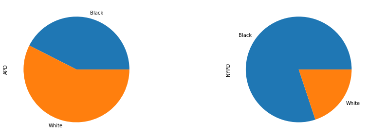

```python
# Pie plots showing breakdown of white vs. black ethnicity in the two areas
pBW_arrests.plot.pie(subplots=True, legend=None, figsize=(15,5))
```

When looking at the pie charts, one can see that both populations are majority white, but more black people are arrested than white people in New York City, and it is almost even in Austin. One can make a weak inference that there may be some racial bias in the NYPD because the population is majority white, but far more black people are arrested than white. Obviously this inference is weak because each arrest has specific cirumstances that cannot be accounted for.

```python
# Check NYPD arrests race values
NYPD_arrests['PERP_RACE'].unique()
```

```
array(['WHITE HISPANIC', 'BLACK', 'BLACK HISPANIC',
       'ASIAN / PACIFIC ISLANDER', 'WHITE', 'UNKNOWN',
       'AMERICAN INDIAN/ALASKAN NATIVE', 'OTHER'], dtype=object)
```

```python
# Remove unknown and other race from NYPD Arrests
NYPD_arrests_clean = NYPD_arrests[(NYPD_arrests['PERP_RACE'] != "OTHER") & (NYPD_arrests['PERP_RACE'] != "UNKNOWN")].copy()
```

```python
NYPD_arrests_clean['PERP_RACE'].unique()
```

```
array(['WHITE HISPANIC', 'BLACK', 'BLACK HISPANIC',
       'ASIAN / PACIFIC ISLANDER', 'WHITE',
       'AMERICAN INDIAN/ALASKAN NATIVE'], dtype=object)
```

```python
# Check NYPD arrests age group values
NYPD_arrests_clean['AGE_GROUP'].unique()
```

```
array(['45-64', '25-44', '18-24', '<18', '65+', nan, '924', '932', '929',
       '941', '930', '940', '922', '928', '945', '955', '936', '927',
       '943', '934', '948', '895', '808', '812', '317', '909', '949',
       '923', '914', '896', '942', '709', '640', '951', '926', '935',
       '925', '212', '931', '200', '954', '894', '314', '937', '723',
       '947', '921', '309', '959', '910', '938', '912', '446', '330',
       '944', '320', '339', '323', '965', '946', 'UNKNOWN', '194', '352',
       '920', '708', '816', '316', '237', '939', '740', '952', '338',
       '933', '1042', '2000', '1937', '1916', '1928', '2007', '1918',
       '1947', '1998', '1953', '1942', '1024', '1948', '1922', '1048',
       '1018', '918'], dtype=object)
```

```python
NYPD_arrests_clean['PERP_RACE'].unique()
```

```
array(['WHITE HISPANIC', 'BLACK', 'BLACK HISPANIC',
       'ASIAN / PACIFIC ISLANDER', 'WHITE',
       'AMERICAN INDIAN/ALASKAN NATIVE'], dtype=object)
```

```python
# Clean NYPD arrests age groups
NYPD_arrests_clean = NYPD_arrests_clean[(NYPD_arrests_clean['AGE_GROUP'] == '<18') | (NYPD_arrests_clean['AGE_GROUP'] == '18-24') | (NYPD_arrests_clean['AGE_GROUP'] == '25-44') | (NYPD_arrests_clean['AGE_GROUP'] == '45-64') | (NYPD_arrests_clean['AGE_GROUP'] == '65+')]
```

```python
#NYPD_arrests_clean['AGE_GROUP'].unique()
NYPD_arrests_clean['PERP_RACE'].unique()
```

```
array(['WHITE HISPANIC', 'BLACK', 'BLACK HISPANIC',
       'ASIAN / PACIFIC ISLANDER', 'WHITE',
       'AMERICAN INDIAN/ALASKAN NATIVE'], dtype=object)
```

type(NYPD_arrests_clean['ARREST_DATE'][0])

```python
# Make a year column
NYPD_arrests_clean['Year'] = pd.DatetimeIndex(NYPD_arrests_clean['ARREST_DATE']).year
NYPD_arrests_clean.head()
```

|  | ARREST_KEY | ARREST_DATE | PD_CD | PD_DESC | KY_CD | OFNS_DESC | LAW_CODE | LAW_CAT_CD | ARREST_BORO | ARREST_PRECINCT | JURISDICTION_CODE | AGE_GROUP | PERP_SEX | PERP_RACE | X_COORD_CD | Y_COORD_CD | Latitude | Longitude | Lon_Lat | Year |
| --- | --- | --- | --- | --- | --- | --- | --- | --- | --- | --- | --- | --- | --- | --- | --- | --- | --- | --- | --- | --- |
| 0 | 144026181 | 06/26/2015 | 639.0 | AGGRAVATED HARASSMENT 2 | 361.0 | OFF. AGNST PUB ORD SENSBLTY & RGHTS TO PRIV | PL 2403002 | M | Q | 102 | 0.0 | 45-64 | M | WHITE HISPANIC | 1031076.0 | 193779.0 | 40.698440 | -73.831130 | POINT (-73.83112953899997 40.69843969400005) | 2015 |
| 1 | 144507595 | 07/14/2015 | 969.0 | TRAFFIC,UNCLASSIFIED INFRACTION | 881.0 | OTHER TRAFFIC INFRACTION | VTL051101A | M | M | 10 | 3.0 | 25-44 | M | WHITE HISPANIC | 984791.0 | 209846.0 | 40.742664 | -73.998049 | POINT (-73.99804910799998 40.74266360800004) | 2015 |
| 2 | 144565062 | 07/16/2015 | 101.0 | ASSAULT 3 | 344.0 | ASSAULT 3 & RELATED OFFENSES | PL 1200001 | M | K | 90 | 0.0 | 18-24 | F | WHITE HISPANIC | 994026.0 | 195548.0 | 40.703414 | -73.964743 | POINT (-73.96474295699994 40.70341366900004) | 2015 |
| 3 | 144500188 | 07/14/2015 | 879.0 | ADM.CODE,UNCLASSIFIED VIOLATION | 675.0 | ADMINISTRATIVE CODE | AC 010125B | V | Q | 103 | 0.0 | 25-44 | M | WHITE HISPANIC | 1037132.0 | 196129.0 | 40.704856 | -73.809271 | POINT (-73.809270971 40.70485576300007) | 2015 |
| 4 | 144216044 | 07/03/2015 | 478.0 | THEFT OF SERVICES, UNCLASSIFIED | 343.0 | OTHER OFFENSES RELATED TO THEFT | PL 1651503 | M | M | 10 | 1.0 | 18-24 | M | WHITE HISPANIC | 984602.0 | 210686.0 | 40.744969 | -73.998731 | POINT (-73.99873112099993 40.74496920800005) | 2015 |

```python
NYPD_arrests_clean['Year'].unique()
```

```
array([2015, 2010, 2018, 2014, 2013, 2012, 2011, 2017, 2016, 2009, 2008,
       2007, 2006, 2019], dtype=int64)
```

```python
# Update NYPD total after cleaning
NYPDtot_filtered = len(NYPD_arrests.index)
```

```python
# Years in census data
ATX_census['YEAR'].unique()
```

```
array([ 1,  2,  3,  4,  5,  6,  7,  8,  9, 10, 11, 12, 13], dtype=int64)
```

```python
# Separate ATX census into 4 individual years + 4yr
ATX_census_2007 = ATX_census[ATX_census['YEAR'] == 9]
ATX_census_2008 = ATX_census[ATX_census['YEAR'] == 10]
ATX_census_2009 = ATX_census[ATX_census['YEAR'] == 11]
ATX_census_2010 = ATX_census[ATX_census['YEAR'] == 13]
ATX_census_4yr = ATX_census[(ATX_census['YEAR'] == 9) | (ATX_census['YEAR'] == 10) | (ATX_census['YEAR'] == 11) | (ATX_census['YEAR'] == 13)]
```

```python
# Check 2010 census vs estimate
ATX_census_2010_censusdata = ATX_census[ATX_census['YEAR'] == 12]
print(len(ATX_census_2010))
print(len(ATX_census_2010_censusdata))
```

```
20
20
```

```python
# Separate NYC census into 4 individual years + 4yr
NYC_census_2007 = NYC_census[NYC_census['YEAR'] == 9]
NYC_census_2008 = NYC_census[NYC_census['YEAR'] == 10]
NYC_census_2009 = NYC_census[NYC_census['YEAR'] == 11]
NYC_census_2010 = NYC_census[NYC_census['YEAR'] == 13]
NYC_census_4yr = NYC_census[(NYC_census['YEAR'] == 9) | (NYC_census['YEAR'] == 10) | (NYC_census['YEAR'] == 11) | (NYC_census['YEAR'] == 13)]
```

```python
NYPD_arrests_clean = NYPD_arrests_clean[NYPD_arrests_clean['ARREST_DATE'].notna()]
```

```python
year = '2015'
race = 'WHITE'
filterDF = NYPD_arrests_clean[(NYPD_arrests_clean['ARREST_DATE'].str.contains(year)) & (NYPD_arrests_clean['PERP_RACE'] == race)]
num = len(filterDF)
print(num)
```

```
40574
```

```python
#Create dummy column for white and black. Minority would be when 'is_white' == 0
NYPD_arrests_clean.loc[:, 'is_white'] = pd.get_dummies(NYPD_arrests_clean['PERP_RACE'])['WHITE']
NYPD_arrests_clean.loc[:, 'is_black'] = pd.get_dummies(NYPD_arrests_clean['PERP_RACE'])['BLACK']
```

```python
# Remove null values from Law Codes
NYPD_arrests_clean = NYPD_arrests_clean[NYPD_arrests_clean['LAW_CAT_CD'].notna()]
```

```python
# Assign values to LAW_CAT_CD indicators to create a ranking of crime severity
LAW_CAT_CD_map = {'I': 1, 'V': 2, 'M': 3, 'F': 4}
NYPD_arrests_clean['LAW_CAT_CD'] = NYPD_arrests_clean['LAW_CAT_CD'].map(LAW_CAT_CD_map)
```

```python
# Felony
print("Felonies")
Ftotal = len(NYPD_arrests_clean[NYPD_arrests_clean['LAW_CAT_CD'] == 4])
print("Total Number of Felonies: " + str(Ftotal))
print("Percentage of Felony Arrests: {:.2f}%".format((Ftotal/NYPDtot_filtered)*100))

whiteF = len(NYPD_arrests_clean[(NYPD_arrests_clean['is_white'] == 1) & (NYPD_arrests_clean['LAW_CAT_CD'] == 4)])
print("White Felonies: " + str(whiteF) + " / {:.2f}%".format((whiteF/Ftotal)*100))
minF = len(NYPD_arrests_clean[(NYPD_arrests_clean['is_white'] == 0) & (NYPD_arrests_clean['LAW_CAT_CD'] == 4)])
print("Minority Felonies: " + str(minF) + " / {:.2f}%".format((minF/Ftotal)*100))
blackF = len(NYPD_arrests_clean[(NYPD_arrests_clean['is_black'] == 0) & (NYPD_arrests_clean['LAW_CAT_CD'] == 4)])
print("Black Felonies: " + str(blackF) + " / {:.2f}%".format((blackF/Ftotal)*100))


print("")

# Misdemeanor
print("Misdemeanors")
Mtotal = len(NYPD_arrests_clean[NYPD_arrests_clean['LAW_CAT_CD'] == 3])
print("Total Number of Misdemeanors: " + str(Mtotal))
print("Percentage of Misdemeanor Arrests: {:.2f}%".format((Mtotal/NYPDtot_filtered)*100))

whiteM = len(NYPD_arrests_clean[(NYPD_arrests_clean['is_white'] == 1) & (NYPD_arrests_clean['LAW_CAT_CD'] == 3)])
print("White Misdemeanors: " + str(whiteM) + " / {:.2f}%".format((whiteM/Mtotal)*100))
minM = len(NYPD_arrests_clean[(NYPD_arrests_clean['is_white'] == 0) & (NYPD_arrests_clean['LAW_CAT_CD'] == 3)])
print("Minority Misdemeanors: " + str(minM) + " / {:.2f}%".format((minM/Mtotal)*100))
blackM = len(NYPD_arrests_clean[(NYPD_arrests_clean['is_black'] == 0) & (NYPD_arrests_clean['LAW_CAT_CD'] == 3)])
print("Black Misdemeanors: " + str(blackM) + " / {:.2f}%".format((blackM/Mtotal)*100))

print("")

# Violation
print("Violations")
Vtotal = len(NYPD_arrests_clean[NYPD_arrests_clean['LAW_CAT_CD'] == 2])
print("Total Number of Violations: " + str(Vtotal))
print("Percentage of Violation Arrests: {:.2f}%".format((Vtotal/NYPDtot_filtered)*100))

whiteV = len(NYPD_arrests_clean[(NYPD_arrests_clean['is_white'] == 1) & (NYPD_arrests_clean['LAW_CAT_CD'] == 2)])
print("White Violations: " + str(whiteV) + " / {:.2f}%".format((whiteV/Vtotal)*100))
minV = len(NYPD_arrests_clean[(NYPD_arrests_clean['is_white'] == 0) & (NYPD_arrests_clean['LAW_CAT_CD'] == 2)])
print("Minority Violations: " + str(minV) + " / {:.2f}%".format((minV/Vtotal)*100))
blackV = len(NYPD_arrests_clean[(NYPD_arrests_clean['is_black'] == 0) & (NYPD_arrests_clean['LAW_CAT_CD'] == 2)])
print("Black Violations: " + str(blackV) + " / {:.2f}%".format((blackV/Vtotal)*100))

print("")

# Traffic Infraction
print("Traffic Infractions")
Itotal = len(NYPD_arrests_clean[NYPD_arrests_clean['LAW_CAT_CD'] == 1])
print("Total Number of Traffic Infractions: " + str(Itotal))
print("Percentage of Traffic Infraction Arrests: {:.2f}%".format((Itotal/NYPDtot_filtered)*100))

whiteI = len(NYPD_arrests_clean[(NYPD_arrests_clean['is_white'] == 1) & (NYPD_arrests_clean['LAW_CAT_CD'] == 1)])
print("White Traffic Infractions: " + str(whiteI) + " / {:.2f}%".format((whiteI/Itotal)*100))
minI = len(NYPD_arrests_clean[(NYPD_arrests_clean['is_white'] == 0) & (NYPD_arrests_clean['LAW_CAT_CD'] == 1)])
print("Minority Traffic Infractions: " + str(minI) + " / {:.2f}%".format((minI/Itotal)*100))
blackI = len(NYPD_arrests_clean[(NYPD_arrests_clean['is_black'] == 0) & (NYPD_arrests_clean['LAW_CAT_CD'] == 1)])
print("Black Traffic Infractions: " + str(blackI) + " / {:.2f}%".format((blackI/Itotal)*100))
```

```
Felonies
Total Number of Felonies: 1327472
Percentage of Felony Arrests: 26.48%
White Felonies: 144335 / 10.87%
Minority Felonies: 1183137 / 89.13%
Black Felonies: 642367 / 48.39%

Misdemeanors
Total Number of Misdemeanors: 3301109
Percentage of Misdemeanor Arrests: 65.85%
White Misdemeanors: 423802 / 12.84%
Minority Misdemeanors: 2877307 / 87.16%
Black Misdemeanors: 1724412 / 52.24%

Violations
Total Number of Violations: 289559
Percentage of Violation Arrests: 5.78%
White Violations: 29860 / 10.31%
Minority Violations: 259699 / 89.69%
Black Violations: 135028 / 46.63%

Traffic Infractions
Total Number of Traffic Infractions: 25607
Percentage of Traffic Infraction Arrests: 0.51%
White Traffic Infractions: 3942 / 15.39%
Minority Traffic Infractions: 21665 / 84.61%
Black Traffic Infractions: 15411 / 60.18%
```

```python
from sklearn.linear_model import LinearRegression
from sklearn.linear_model import LogisticRegression
from sklearn.model_selection import train_test_split

## Set up properly-shaped arrays for x and y values for regression
x = NYPD_arrests_clean[['is_white']]
y = NYPD_arrests_clean['LAW_CAT_CD']

## Perform the regression
model = LinearRegression().fit(x, y)

## Print regression coefficients
print("slope for 'LAW_CAT_CD' is {:.3f}".format(model.coef_[0]))
print("intercept for 'LAW_CAT_CD' is {:.3f}".format(model.intercept_))
```

```
slope for 'LAW_CAT_CD' is -0.026
intercept for 'LAW_CAT_CD' is 3.203
```

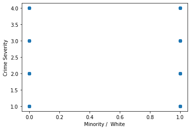

```python
x = NYPD_arrests_clean['is_white']
y = NYPD_arrests_clean['LAW_CAT_CD']
plt.scatter(x, y, alpha=0.3)
plt.xlabel('Minority /  White')
plt.ylabel('Crime Severity')
```

```python
# Calculate number of arrests for each year, by race
races = NYPD_arrests_clean['PERP_RACE'].unique()
years = NYPD_arrests_clean['Year'].unique()
data = []
for year in years:
    for race in races:
        filterDF = NYPD_arrests_clean[(NYPD_arrests_clean['ARREST_DATE'].str.contains(str(year))) & (NYPD_arrests_clean['PERP_RACE'] == race)]
        num = len(filterDF)
        row = []
        row.append(year)
        row.append(race)
        row.append(num)
        data.append(row)
```

```python
# Add the values to a new dataframe
NYPD_arrests_byYearRace = pd.DataFrame(data, columns = ['Year', 'Race', 'Number_of_Arrests'])
NYPD_arrests_byYearRace.head()
```

|  | Year | Race | Number_of_Arrests |
| --- | --- | --- | --- |
| 0 | 2015 | WHITE HISPANIC | 86417 |
| 1 | 2015 | BLACK | 163409 |
| 2 | 2015 | BLACK HISPANIC | 28315 |
| 3 | 2015 | ASIAN / PACIFIC ISLANDER | 15332 |
| 4 | 2015 | WHITE | 40391 |

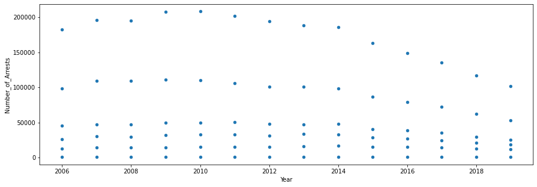

```python
NYPD_arrests_byYearRace.plot.scatter('Year', 'Number_of_Arrests', figsize=(15,5))
```

```python
## Set up properly-shaped arrays for x and y values for regression
x = NYPD_arrests_byYearRace[['Year']]
y = NYPD_arrests_byYearRace['Number_of_Arrests']

## Perform the regression
model_byYR = LinearRegression().fit(x, y)

## Print regression coefficients
print("slope is {:.3f}".format(model_byYR.coef_[0]))
print("intercept is {:.3f}".format(model_byYR.intercept_))
```

```
slope is -2186.381
intercept is 4458945.060
```

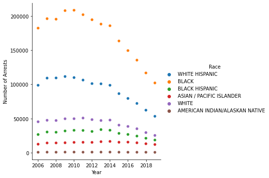

```python
sns.relplot(x='Year', y='Number_of_Arrests', hue='Race', data=NYPD_arrests_byYearRace, kind='scatter');
plt.xlabel('Year')
plt.ylabel('Number of Arrests')
```

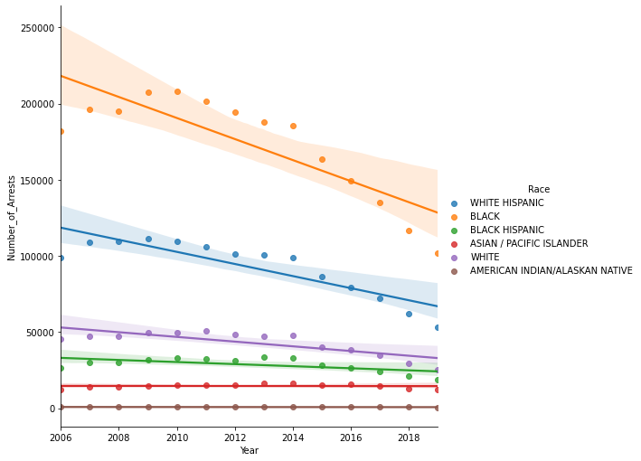

```python
sns.lmplot(x='Year', y='Number_of_Arrests', hue='Race', height=7, data=NYPD_arrests_byYearRace)
```

```python
NYPD_arrests_byYearRace_BLACK = NYPD_arrests_byYearRace[NYPD_arrests_byYearRace['Race'] == 'BLACK']
```

```python
## Set up properly-shaped arrays for x and y values for regression
x = NYPD_arrests_byYearRace_BLACK[['Year']]
y = NYPD_arrests_byYearRace_BLACK['Number_of_Arrests']

## Perform the regression
model_byYR_Black = LinearRegression().fit(x, y)

## Print regression coefficients
print("slope is {:.3f}".format(model.coef_[0]))
print("intercept is {:.3f}".format(model.intercept_))
y_byYR_BLACK_pred = model.predict(x)  # make predictions
```

```
slope is -0.026
intercept is 3.203
```

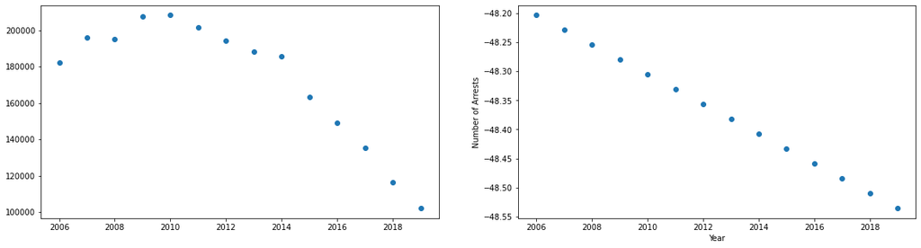

```python
fig = plt.figure(figsize=(20,5))
ax1 = fig.add_subplot(121)
ax2 = fig.add_subplot(122)
x = NYPD_arrests_byYearRace_BLACK['Year']
y = NYPD_arrests_byYearRace_BLACK['Number_of_Arrests']
ax1.scatter(x, y)
ax2.scatter(x, y_byYR_BLACK_pred)
plt.xlabel('Year')
plt.ylabel('Number of Arrests')
```

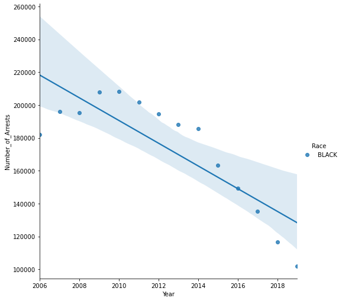

```python
sns.lmplot(x='Year', y='Number_of_Arrests', hue='Race', height=7, data=NYPD_arrests_byYearRace_BLACK)
```

```python
# Correlation between Year and Number of Arrests when race is Black
# This shows how closely the number of arrests follows the linear increase of time
print("R-squared: " + str(model_byYR_Black.score(NYPD_arrests_byYearRace_BLACK[['Year']], NYPD_arrests_byYearRace_BLACK['Number_of_Arrests'])))
```

```
R-squared: 0.6988857892190199
```

```python
# Filter by just years
years = NYPD_arrests_clean['Year'].unique()
dataYr = []
for year in years:
        filterYr = NYPD_arrests_clean[NYPD_arrests_clean['ARREST_DATE'].str.contains(str(year))]
        numYr = len(filterYr)
        dataYr.append(numYr)
print(dataYr)
```

```
[334637, 416790, 243368, 382380, 386886, 391036, 407467, 282140, 310212, 416221, 396771, 398033, 365964, 211842]
```

```python
# Checking how difference in number of arrests between 2014-2019 and 2008-2013
# Doing this to confirm that number of overall arrests is not decreasing
recent6yrs = dataYr[len(dataYr)-6:len(dataYr)]
prev6yrs = dataYr[len(dataYr)-12:len(dataYr)-6]
print(recent6yrs)
print(sum(recent6yrs))
print(sum(prev6yrs))
```

```
[310212, 416221, 396771, 398033, 365964, 211842]
2099043
2093277
```

```python
# Average number of arrests per year, per race
sumNum = NYPD_arrests_byYearRace['Number_of_Arrests'].sum()
print(sumNum)
lenNum = len(NYPD_arrests_byYearRace)
print(lenNum)
meanNum2 = sumNum / lenNum
print(meanNum2)

meanNum = NYPD_arrests_byYearRace['Number_of_Arrests'].mean()
print(meanNum)
```

```
4943747
84
58854.130952380954
58854.130952380954
```

```python
NYPD_arrests_byYearRace['meanNum'] = meanNum
NYPD_arrests_byYearRace_BLACK['meanNum'] = meanNum
```

```python
NYPD_arrests_byYearRace_BLACK.head()
```

|  | Year | Race | Number_of_Arrests | meanNum |
| --- | --- | --- | --- | --- |
| 1 | 2015 | BLACK | 163409 | 58854.130952 |
| 7 | 2010 | BLACK | 208360 | 58854.130952 |
| 13 | 2018 | BLACK | 116652 | 58854.130952 |
| 19 | 2014 | BLACK | 185666 | 58854.130952 |
| 25 | 2013 | BLACK | 188106 | 58854.130952 |

```python
# Filter for serious crimes
races = NYPD_arrests_clean['PERP_RACE'].unique()
years = NYPD_arrests_clean['Year'].unique()
dataC = []
for year in years:
    for race in races:
        filterCrimeL = NYPD_arrests_clean[(NYPD_arrests_clean['ARREST_DATE'].str.contains(str(year))) & (NYPD_arrests_clean['PERP_RACE'] == race) & (NYPD_arrests_clean['LAW_CAT_CD'] > 2)]
        numSC = len(filterCrimeL)
        dataC.append(numSC)
```

```python
# Create a column that indicates the number of arrests per year, by race that are misdemeanors or felonies
NYPD_arrests_byYearRace['Serious_Crime_Number'] = dataC
```

```python
NYPD_arrests_byYearRace.head()
```

|  | Year | Race | Number_of_Arrests | meanNum | Serious_Crime_Number |
| --- | --- | --- | --- | --- | --- |
| 0 | 2015 | WHITE HISPANIC | 86417 | 58854.130952 | 79383 |
| 1 | 2015 | BLACK | 163409 | 58854.130952 | 149166 |
| 2 | 2015 | BLACK HISPANIC | 28315 | 58854.130952 | 26582 |
| 3 | 2015 | ASIAN / PACIFIC ISLANDER | 15332 | 58854.130952 | 14683 |
| 4 | 2015 | WHITE | 40391 | 58854.130952 | 37949 |

```python
# Filter for younger age groups
races = NYPD_arrests_clean['PERP_RACE'].unique()
years = NYPD_arrests_clean['Year'].unique()
dataYA = []
for year in years:
    for race in races:
        filterYAgeGrp = NYPD_arrests_clean[(NYPD_arrests_clean['ARREST_DATE'].str.contains(str(year))) & (NYPD_arrests_clean['PERP_RACE'] == race) & ((NYPD_arrests_clean['AGE_GROUP'] == '<18') | (NYPD_arrests_clean['AGE_GROUP'] == '18-24'))]
        numYAG = len(filterYAgeGrp)
        dataYA.append(numYAG)
```

```python
# Create a column that indicates the number of arrests per year, by race where people are younger than 24
NYPD_arrests_byYearRace['Young_Age'] = dataYA
```

```python
NYPD_arrests_byYearRace.head()
```

|  | Year | Race | Number_of_Arrests | meanNum | Serious_Crime_Number | Young_Age |
| --- | --- | --- | --- | --- | --- | --- |
| 0 | 2015 | WHITE HISPANIC | 86417 | 58854.130952 | 79383 | 28661 |
| 1 | 2015 | BLACK | 163409 | 58854.130952 | 149166 | 55792 |
| 2 | 2015 | BLACK HISPANIC | 28315 | 58854.130952 | 26582 | 11138 |
| 3 | 2015 | ASIAN / PACIFIC ISLANDER | 15332 | 58854.130952 | 14683 | 4546 |
| 4 | 2015 | WHITE | 40391 | 58854.130952 | 37949 | 9319 |

```python
# Filter for older age groups
races = NYPD_arrests_clean['PERP_RACE'].unique()
years = NYPD_arrests_clean['Year'].unique()
dataOA = []
for year in years:
    for race in races:
        filterOAgeGrp = NYPD_arrests_clean[(NYPD_arrests_clean['ARREST_DATE'].str.contains(str(year))) & (NYPD_arrests_clean['PERP_RACE'] == race) & ((NYPD_arrests_clean['AGE_GROUP'] == '25-44') | (NYPD_arrests_clean['AGE_GROUP'] == '45-64') | (NYPD_arrests_clean['AGE_GROUP'] == '65+'))]
        numOAG = len(filterOAgeGrp)
        dataOA.append(numOAG)
```

```python
# Create a column that indicates the number of arrests per year, by race where people are older than 24
NYPD_arrests_byYearRace['Old_Age'] = dataOA
```

```python
NYPD_arrests_byYearRace.head()
```

|  | Year | Race | Number_of_Arrests | meanNum | Serious_Crime_Number | Young_Age | Old_Age |
| --- | --- | --- | --- | --- | --- | --- | --- |
| 0 | 2015 | WHITE HISPANIC | 86417 | 58854.130952 | 79383 | 28661 | 57756 |
| 1 | 2015 | BLACK | 163409 | 58854.130952 | 149166 | 55792 | 107617 |
| 2 | 2015 | BLACK HISPANIC | 28315 | 58854.130952 | 26582 | 11138 | 17177 |
| 3 | 2015 | ASIAN / PACIFIC ISLANDER | 15332 | 58854.130952 | 14683 | 4546 | 10786 |
| 4 | 2015 | WHITE | 40391 | 58854.130952 | 37949 | 9319 | 31072 |

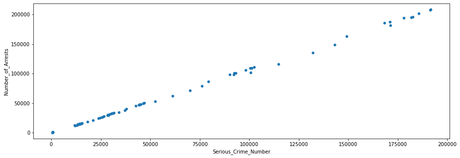

```python
NYPD_arrests_byYearRace.plot.scatter('Serious_Crime_Number', 'Number_of_Arrests', figsize=(15,5))
```

```python
# Perform the regression
model_byYR_Crime = LinearRegression().fit(NYPD_arrests_byYearRace[['Serious_Crime_Number']], NYPD_arrests_byYearRace['Number_of_Arrests'])

# Print regression coefficients
print("slope is {:.3f}".format(model_byYR_Crime.coef_[0]))
print("intercept is {:.3f}".format(model_byYR_Crime.intercept_))
print("R-squared: " + str(model_byYR_Crime.score(NYPD_arrests_byYearRace[['Serious_Crime_Number']], NYPD_arrests_byYearRace['Number_of_Arrests'])))
y_byYR_Crime_pred = model_byYR_Crime.predict(NYPD_arrests_byYearRace[['Serious_Crime_Number']])  # make predictions
```

```
slope is 1.081
intercept is -732.226
R-squared: 0.9991038007089764
```

```python
# Perform the regression
model_byYR_YA = LinearRegression().fit(NYPD_arrests_byYearRace[['Young_Age']], NYPD_arrests_byYearRace['Number_of_Arrests'])

# Print regression coefficients
print("slope is {:.3f}".format(model_byYR_YA.coef_[0]))
print("intercept is {:.3f}".format(model_byYR_YA.intercept_))
print("R-squared: " + str(model_byYR_YA.score(NYPD_arrests_byYearRace[['Young_Age']], NYPD_arrests_byYearRace['Number_of_Arrests'])))
y_byYR_YA_pred = model_byYR_YA.predict(NYPD_arrests_byYearRace[['Young_Age']])  # make predictions
```

```
slope is 2.673
intercept is 4469.436
R-squared: 0.9833363510105009
```

```python
## Set up properly-shaped arrays for x and y values for regression
x = NYPD_arrests_byYearRace[['Old_Age']]
y = NYPD_arrests_byYearRace['Number_of_Arrests']

## Perform the regression
model_byYR_OA = LinearRegression().fit(x, y)

## Print regression coefficients
print("slope is {:.3f}".format(model_byYR_OA.coef_[0]))
print("intercept is {:.3f}".format(model_byYR_OA.intercept_))
print("R-squared: " + str(model_byYR_OA.score(NYPD_arrests_byYearRace[['Old_Age']], NYPD_arrests_byYearRace['Number_of_Arrests'])))
y_byYR_OA_pred = model_byYR_OA.predict(NYPD_arrests_byYearRace[['Old_Age']])  # make predictions
```

```
slope is 1.573
intercept is -1717.000
R-squared: 0.9942940398803016
```

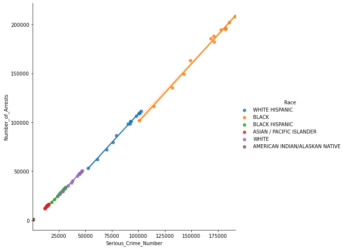

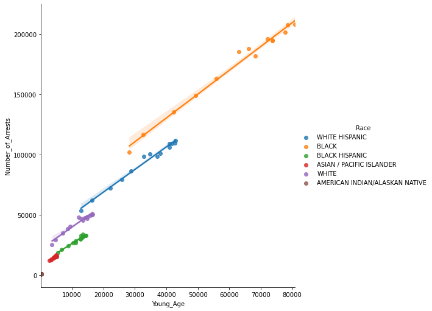

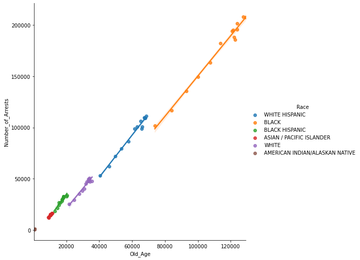

```python
sns.lmplot(x='Serious_Crime_Number', y='Number_of_Arrests', hue='Race', height=7, data=NYPD_arrests_byYearRace)
sns.lmplot(x='Young_Age', y='Number_of_Arrests', hue='Race', height=7, data=NYPD_arrests_byYearRace)
sns.lmplot(x='Old_Age', y='Number_of_Arrests', hue='Race', height=7, data=NYPD_arrests_byYearRace)
```

## Interpretation and Conclusions

I started by breaking down number of arrests for white and black, as well as census data for black and white, both male and females, and comparing these values. When looking at all of the arrest data as a whole, one can see that New York City roughly half of all arrests involved black people. When looking at the census, a little under a third of the population identified as African American. In Austin, a quarter of people arrested were black. According to the census, only 10% of people identified as African American.

When looking at these numbers, one must remember that everything has different time frames for years. So while this data might appear to indicate that people who identify as African American are arrested significantly more than the demographics would suggest they should be, if every race was arrested at an equal rate. While each race will never be arrested at the exact same rate as their representation in the census data because of the random nature of crime, one can start to make inferences when there is a significant disparity.

After looking at the arrest records overall, using the census data as context, one could make some weak inferences that there is racial bias. I spent a lot of time trying contemplating how I could continue my investigation after my inital statistics.

I came to the conclusion that I needed to incorporate time. The NYPD arrests has the longest timeframe and the most data overall, so I changed the focus of my investigation, shifting past my initial ideas for analysis. I knew that I needed to find to variables that I could find the correlation between them with regression.

I spent some time cleaning up the NYPD Arrest Records, taking out inconsistent values from age group, arrest date, race, and the "LAW_CAT_CD" column, which represents the "level" of the crime (felony, misdemeanor, etc.). I needed to keep true to my overall research questions and analyze these based on race. So, I created a new dataframe with Year, Race and Number of Arrests. I created for loops that would find the number of rows that corresponded with every year and race combination and added them to this new dataframe.

Next, I made some a scatter plot and looked at regression coefficients to investigate the relationship between the year, time, and the number of arrests. The slope of the regression was not very helpful here, as the scatter plot with all races came out with something that looked like an individual scatter plot for each race stacked on top of each other. There was not very much significant statistical analysis to be found here.

Next, I wanted to see how some other variables would correlate with the number of arrests. I wanted to look at Age and Crime Level. To do this, I created more columns in the newer dataframe, Young_Age, Old_Age and Serious_Crime_Number. Young Age consists of anyone under 25, Old age is 25 and over, and Serious Crime is anything that is a misdemeanor or felony. All of the slopes were positive, and Young Age had the highest slope value. This indicates that the younger a person is, the more likely they are to be arrested. It makes sense that they all have positive slopes, as for each year and race, increasing number of arrests based on something, will also increase the overall number of arrests. The significantt analysis from this is the difference in slope between these variables. The R-squared values were all really high, indicating a strong relationship between the regression and the points, but not offering any significant analysis. If the slope has a higher value, this should indicate that that variable has more of an impact on the overall number of arrests, for the speific year and race, showing a trend. Thus, I can conclude that Age has a fairly big impact on any race's likelihood to be arrested. Level of Crime or Number of Serious Crimes has a fairly low impact on the overall number of arrests.

If I were to continue my analysis, I would look at the impact these variables have on each race's arrest numbers over time to build a better picture, more racial bias focused.

## Limitations

This investigation was limited primarily by the nature of arrest records. Personal information is witheld in public datasets like these, no name or many distinctive features. I only had age and race as identifying variables here really, which forced me to get creative and look at arrest numbers by year and implement the census data for context.

There were also limitations with the timeframes of every individual dataset. The Arrest records were more recent than the census data and they all have different lengths of time. The census data lined up, 2000 to 2010, so analysis was easier there, but APD arrest records were from 2014 to 2019 and NYPD arrest records were from 2006 - 2019. So I did consider breaking everything into four year chunks, but later decide to break everything down by year to attempt to find more significant analysis.

My last limitation was that the census data was only aggregate data, not individual data. Meaning that there were no individual things that could be plotted on an X and Y axis, only summary statistics. But, my most interesting analysis from the arrest records did end up being aggregate data or sorts, so I'm not certain that the arrest records being individual data was very helpful. I did not realize this at first, and will be sure to look for variables that could be used in regression and analysis down the road before I commit to a dataset.